# Visualisierung von skalaren Feldern mit Hilfe von Isolinien

**Manfred Brill, Hochschule Kaiserslautern**

## Skalare Felder

In diesem Notebook betrachten wir die Visualisierung von skalaren Feldern von zwei reellen Veränderlichen. Beispiele für solche Felder haben wir in der Vorlesung kennen gelernt, diese verwenden wir auch in diesem Notebook. Deshalb importieren wir an dieser Stelle NumPy und implementieren die Felder als Python-Funktion.

```python
import numpy as np

def sinsin(x, y):
    return -np.sin(x)*np.sin(y)
```

## Konturlinien

Wir erzeugen ein Gitter, genauer gesagt ein *meshgrid*, im Defintionsbereich des skalaren Felds, die Funktionswerte der Gitterpunkt berechnen und diese diskrete Datenstruktur an die Funktionen übergeben, die die Konturlinien berechnen und grafisch ausgeben.

```python
n = 200
x = np.linspace(0, 1.0*np.pi, n)
y = np.linspace(0, 2.0*np.pi, n)
x, y = np.meshgrid(x, y)
z = sinsin(x, y)
```

### Matplotlib

Mit Matplotlib verwenden wir die Funktion *plt.contour*. Wir legen vorher fest welche Werte die Konstante C annehmen soll. Wieder verwenden wir eine Farbtabelle um die Werte für die Isolinien anzuzeigen.

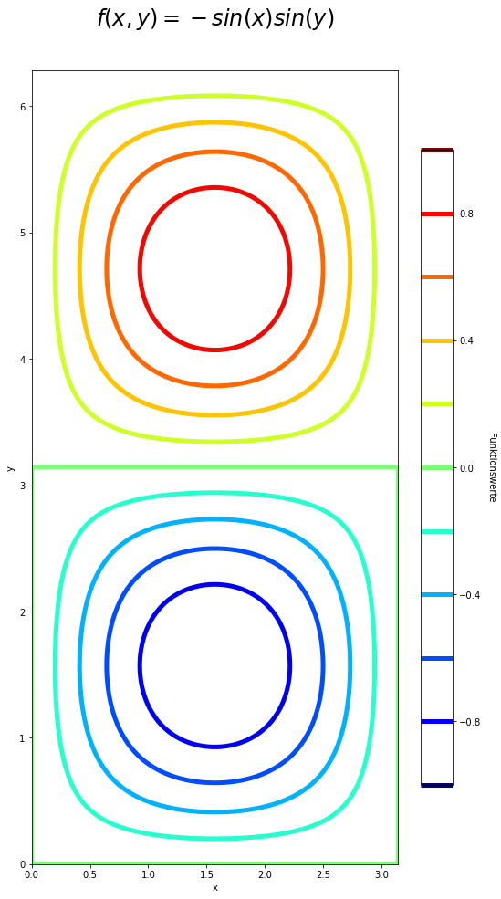

```python
import matplotlib.pyplot as plt
from matplotlib import cm

Cmin = -1.0
Cmax = 1.0
Cstep = 0.2
levels = np.arange(Cmin, Cmax+Cstep, Cstep)

fig = plt.figure(figsize=(9.0, 16.0))
cplot = plt.contour(x, y, z,
                    levels=levels,
                    cmap=cm.jet,
                    linewidths=5
                    )

plt.xlabel('x')
plt.ylabel('y')
plt.title('$f(x, y) = -sin(x) sin(y)$',
          y=1.05,
          fontsize=24)
# Die nächste Zeile kommentieren wenn wir keine Labels in
# den Konturlinien haben möchten
#plt.clabel(cplot, inline=1, fontsize=12)
cbar = plt.colorbar(cplot, shrink=0.8)
cbar.ax.get_yaxis().labelpad = 15
cbar.ax.set_ylabel('Funktionswerte', rotation=270)

plt.show()
```

### Plotly

In Plotly verwenden wir die Funktion *Contour* aus *graph_objs*. Wie schon bei Heatmaps müssen wir uns auch hier darum kümmern die Achsenbeschriftungen anzupassen. Sonst erhalten wir die Gitter-Indizes als Beschriftung.

```python
import plotly.graph_objs as go
import plotly.io as pio

pio.renderers.default = 'notebook_connected+jupyterlab'

fig = go.Figure(data=
              go.Contour(
                   z=z,
                   contours_coloring='lines',
                   line_width=2,
                   colorscale='Jet'
    )
)

fig.update_layout(
    title="f(x, y) = -sin(x) sin(y)",
    font=dict(
        size=18
    ),
    width=600,
    height=800,
    xaxis = dict(
        tickmode = 'array',
        tickvals = [0, 99, 199],
        ticktext = ['0', 'pi/2', 'pi']
    ),
    yaxis = dict(
        tickmode = 'array',
        tickvals = [0, 99, 199],
        ticktext = ['0', 'pi', '2 pi']
    )
)

fig.show()
```

[interactive chart not shown]

Die Funktion *Contour* verwendet Defaultwerte für die Konturwerte. Natürlich können wir diese auch setzen, wie schon für Matplotlib. Dazu setzen wir den Parameter *contours* als dictionary.

```python
fig = go.Figure(data=
              go.Contour(
                   z=z,
                   contours_coloring='lines',
                   line_width=2,
                   colorscale='Jet',
                   contours=dict(
                       start=-1.0,
                       end=1.0,
                       size=0.1,
                  ),
    )
)

fig.update_layout(
    title="f(x, y) = -sin(x) sin(y)",
    font=dict(
        size=18
    ),
    width=600,
    height=800,
    xaxis = dict(
        tickmode = 'array',
        tickvals = [0, 99, 199],
        ticktext = ['0', 'pi/2', 'pi']
    ),
    yaxis = dict(
        tickmode = 'array',
        tickvals = [0, 99, 199],
        ticktext = ['0', 'pi', '2 pi']
    )
)

fig.show()
```

[interactive chart not shown]

Interessant in der Funktion *Contour* ist, dass wir eine Mischung zwischen Konturlinien und einer Heatmap berechnen können. Dazu lassen wir den Parameter *contours_coloring* einfach weg. Dann werden die Isolinien ausgegeben und die Zwischenräume werden mit der Farbtabelle ausgefüllt.

```python
fig = go.Figure(data=
              go.Contour(
                   z=z,
                  # contours_coloring='lines',
                   line_width=2,
                   colorscale='Jet',
                   contours=dict(
                       start=-1.0,
                       end=1.0,
                       size=0.2,
                  ),
    )
)

fig.update_layout(
    title="f(x, y) = -sin(x) sin(y)",
    font=dict(
        size=18
    ),
    width=600,
    height=800,
    xaxis = dict(
        tickmode = 'array',
        tickvals = [0, 99, 199],
        ticktext = ['0', 'pi/2', 'pi']
    ),
    yaxis = dict(
        tickmode = 'array',
        tickvals = [0, 99, 199],
        ticktext = ['0', 'pi', '2 pi']
    )
)

fig.show()
```

[interactive chart not shown]